# Week 1 - Boot Camp II

Linda Kukolich

January 30, 2015

# Hypothesis Testing

- Hypothesis testing is concerned with making decisions using data
- A null hypothesis is specified that represents the status quo, usuallaly labeled $H_0$
- The null hypothesis is assumed true and statistical evidence is required to reject it in favor of a research or alternative hypothesis

### Example

- A repiratory disturbance index of more than 30 events / hour, say, is considered evidence of severe sleep disordered breathing (SDB)
- Suppose that in a sample of 100 overweight subjects with other risk factors for sleep disordered breathing at a sleep clinic, the mean RDI was 32 events / hour with a standard deviation of 10 events / hour
- We might want to test the hypothesis that
  - $H_0 : \mu = 30$
  - $H_a : \mu > 30$ where $\mu$ is the population mean RDI
- Note that there are four possible outcomes of our statistical decision process

| Truth | $H_0$ | $H_a$ |
| --- | --- | --- |
| $H_0$ | Correctly accept null | Type 1 error |
| $H_a$ | Type II error | Correctly reject null |

### Discussion

- Consider a court of law; the null hypothesis is that the defendant is innocent
- We require evidence to reject the null hypothesis (convict)
- If we require little evidence, then we would increase the percentage of innocent people convicted (type I errors); however, we would also increase the percentage of guilty people convicted (correctly rejecting the null)
- If we require a lot of evidence, then we increase the percentage of innocent people let free (correctly accepting the null) while we would also increase the percentage of guilty people let free (type II errors)

### Example again

- A resonable strategy would reject the null hypothesis if $\bar{X}$ was larger than some constant, say C
- Typically, C is chosen so that the probability of a Type 1 error, $\alpha$, is 0.05 (or some other relevant constant)
- $\alpha$ = Type 1 error rate = Probability of rejecting the null hypothesis when, in fact, the null hypothesis is correct.

That is, keep the false alarms low by controlling for it, usually 5% false alarm.

- Find a constant, C, such that the probability of false alarm (probability of the mean being more than C) is 0.05 given a true population mean of 30.
- normalize the data to give a 0 mean and unit variance. That is, subtract the mean $\mu$ and divide by the variance $sd/\sqrt{n}$ on both sides of the inequality
- Notice that the first is just a Z (standard normal distribution) and solve for C on the other side

$\begin{aligned} .05 & = P\big(\bar{X} \ge C \,|\, \mu = 30\big) \\ & = P\big(\frac{\bar{X} - 30}{10/\sqrt{100}} \ge \frac{C - 30}{10/\sqrt{100}} \,|\, \mu = 30\big) \\ & = P\big(Z \ge \frac{C - 30}{1}\big) \end{aligned}$

```r
mu <- 30
xbar <- 32
sd <- 10
n <- 100
ts <- (xbar - mu)/(sd/sqrt(n))
z05 <- qnorm(1-0.05)
paste(ts, "<", z05)
```

```
## [1] "2 < 1.64485362695147"
```

```r
if(ts < z05) {
    print("reject null hypothesis")
} else {
    print("fail to reject null hypothesis (accept Ha)")
}
```

```
## [1] "fail to reject null hypothesis (accept Ha)"
```

- Hence $(C - 30)/1 = 1.645$ implying $C = 31.645$
- Since our mean is 32 we reject the null hypothesis

```r
qnorm(.95)
```

```
## [1] 1.644854
```

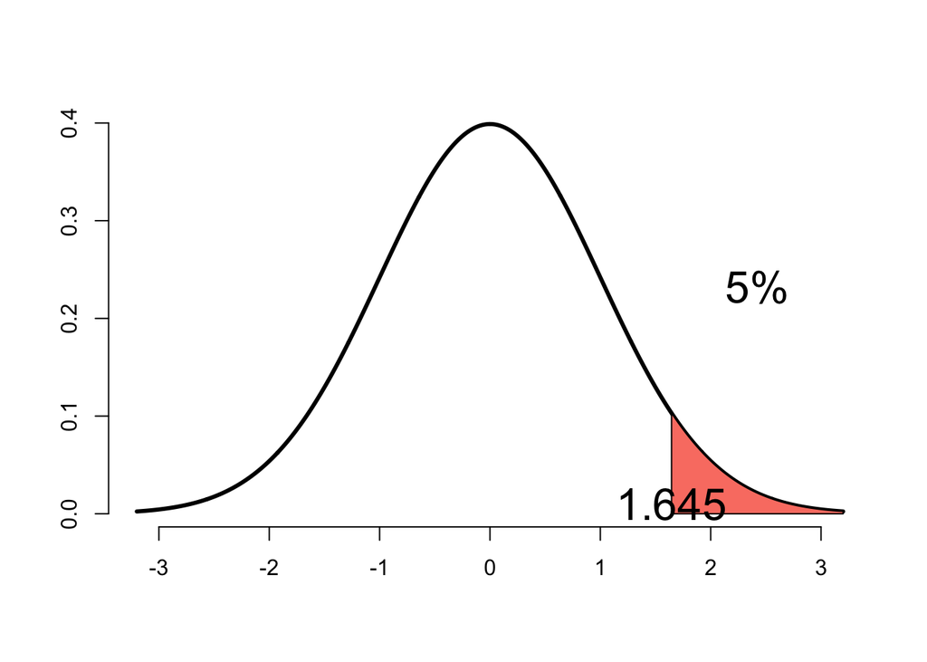

```r
xval <- seq(-3.2, 3.2, length = 1000)
yval <- dnorm(xval)
plot(xval, yval, type = "l", axes = TRUE, frame = FALSE, lwd = 3, xlab = "", ylab="")
x <- seq(qnorm(.95), 3.2, length = 100)
polygon(c(x, rev(x)), c(dnorm(x), rep(0, length(x))), col = "salmon")
text(mean(x), mean(dnorm(x))+0.2, "5%", cex = 2)
text(qnorm(.95), 0.01, "1.645", cex = 2)
```

### Discussion

- In general we don’t convert C back to the original scale
- We would just reject because the Z-score; which is how many standard errors the sample mean is above the hypothesized mean

Reject null hypothesis when: $\frac{\bar{X} - \mu}{\sigma/\sqrt{n}} \ge Z_\alpha \\ \frac{32 - 30}{10/\sqrt{100}} = 2$

is greater than 1.645

## General Rule

- The Z test for $H_0 : \mu = \mu_0$ versus
  - $H_1 : \mu \le \mu_0$
  - $H_2 : \mu \ne \mu_0$
  - $H_3 : \mu \gt \mu_0$
- Test statistic $TS = \frac{\bar{X} - \mu_0}{S/\sqrt{n}}$
- Reject the null hypothesis when
  - $H_1 : TS \le - Z_{1-\alpha}$
  - $H_2 : |TS| \ge Z_{1-\alpha/2}$
  - $H_3 : TS \ge Z_{1-\alpha}$

## Two sided Z test

Halve the alpha, so half the error comes from below and half from above.

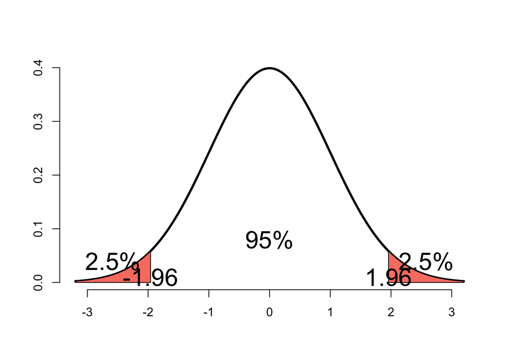

```r
plot(xval, yval, type = "l", axes = TRUE, frame = FALSE, lwd = 3, xlab = "", ylab = "")
x <- seq(qnorm(.975), 3.2, length = 100)
polygon(c(x, rev(x)), c(dnorm(x), rep(0, length(x))), col = "salmon")
text(mean(x), mean(dnorm(x))+0.02, "2.5%", cex = 2)
text(qnorm(0.975), 0.01, "1.96", cex = 2)
x <- seq(-3.2, qnorm(0.025), length = 100)
polygon(c(x, rev(x)), c(dnorm(x), rep(0, length(x))), col = "salmon")
text(mean(x), mean(dnorm(x)) + 0.02, "2.5%", cex = 2)
text(qnorm(0.025), 0.01, "-1.96", cex = 2)
text(0, dnorm(0)/5, "95%", cex = 2)
```

## Notes

- We have fixed $\alpha$ to be low, so if we reject $H_0$ (either our model is wrong) or there is a low probability that we have made an error
- We have not fixed the probabilitiy of a type II error, $\beta$; therefore we tend to say “Fail to reject $H_0$” rather than accepting $H_0$ (You may not have enough data, for instance, to really make a positive statement)
- Statistical significance is not the same as scientific significance
- The region of TS values for which you reject $H_0$ is called the rejection region (The salmon part on his graphs)

## Smaller data sets, CLT does not apply

- The Z test requires the assumptions of the Central Limit Theorem and for n to be large enough for it to apply
- If n is small, then a Gossett’s T test is performed exactly in the same way, with the normal quantiles replaced by the approriate Student’s T quantiles and n-1 degrees of freedom
- The probability of rejecting the null hypothesis when it is false is called **power**
- Power is used a lot to calculate sample sizes for experiments

### Example reconsidered

Consider our example again. Suppose that n = 16 rather than 100. Then consider that

$0.5 = P\big(\frac{(\bar{X} - 30)}{s/\sqrt{16}} \ge t_{1-\alpha,15} \,|\, \mu = 30 \big)$

## Two Sided Tests

- Suppose that we would reject the null hypothesis if in fact the mean was too large or two small
- That is, we want to test the alternative $H_a \mu \ne 30$ (doesn’t make a lot of sense in our setting)
- Then note

$\alpha = P \big( \big| \frac{\bar{X} - 30}{s / \sqrt{16}} \big| \gt t_{1-\alpha/2,15} \big| \mu = 30 \big)$

- That is, we will reject if the test statistic, 0.8, is either too large or too small, but the critical value is calculated using $\alpha/2$ In our example the critical value is 2.13, so we still fail to reject (unsurprisingly, given that the 2-sided test is harder and we failed the 1-sided test)

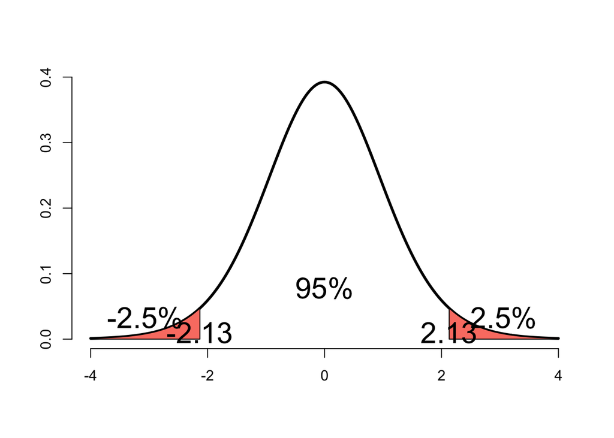

```r
xval <- seq(-4, 4, length = 1000)
yval <- dt(xval, 15)
plot(xval, yval, type = "l", axes = TRUE, frame = FALSE, lwd = 3, xlab = "", ylab = "")
x <- seq(qt(.975, 15), 4, length = 100)
polygon(c(x, rev(x)), c(dt(x, 15), rep(0, length(x))), col = "salmon")
text(mean(x), mean(dt(x, 15))+0.02, "2.5%", cex = 2)
text(qt(0.975, 15), 0.01, "2.13", cex = 2)
x <- seq(-4, qt(0.025, 15), length = 100)
polygon(c(x, rev(x)), c(dt(x, 15), rep(0, length(x))), col = "salmon")
text(mean(x), mean(dt(x, 15)) + 0.02, "-2.5%", cex = 2)
text(qt(0.025, 15), 0.01, "-2.13", cex = 2)
text(0, dt(0, 15)/5, "95%", cex = 2)
```

## Confidence Intervals

### Proof

- Consider that we do not reject $H_0$ if

$\big| \frac{\bar{x} - \mu_0}{s/\sqrt{n}} \big| \le t_{1-\alpha/2,n-1}$

implying

$| \bar{X} - \mu_0 | \le t_{1-\alpha/2,n-1} s/\sqrt{n}$

implying

$\bar{X} - t_{1-\alpha/2, n-1} s/\sqrt{n} \lt \mu_0 \lt \bar{X} + t_{1-\alpha/2, n-1} s/\sqrt{n}$

## P-Values

- Notice that we rejected the one sided test when $\alpha = 0.05$, would we reject if $\alpha = 0.01$, how about 0.001?
- The smallest value for alpha that you still reject the null hypothesis is called the **attained significance level**
- This is equvalent, but philosophically a little different from the **P-value**
- The P-value is probability under the null hypothesis of obtaining evidence as extreme or more extreme than would be observed by chance alone
- If the P-value is small, then either $H_0$ is true and we have observed a rare event, or $H_0$ is false
- It tells us how good our Z/T statistic is

### Example

In our example the T statistic was 0.8. What’s the probability of getting a T statistic as large as 0.8?

```r
pt(0.8, 15, lower.tail = FALSE) ## works out to be 0.22
```

```
## [1] 0.218099
```

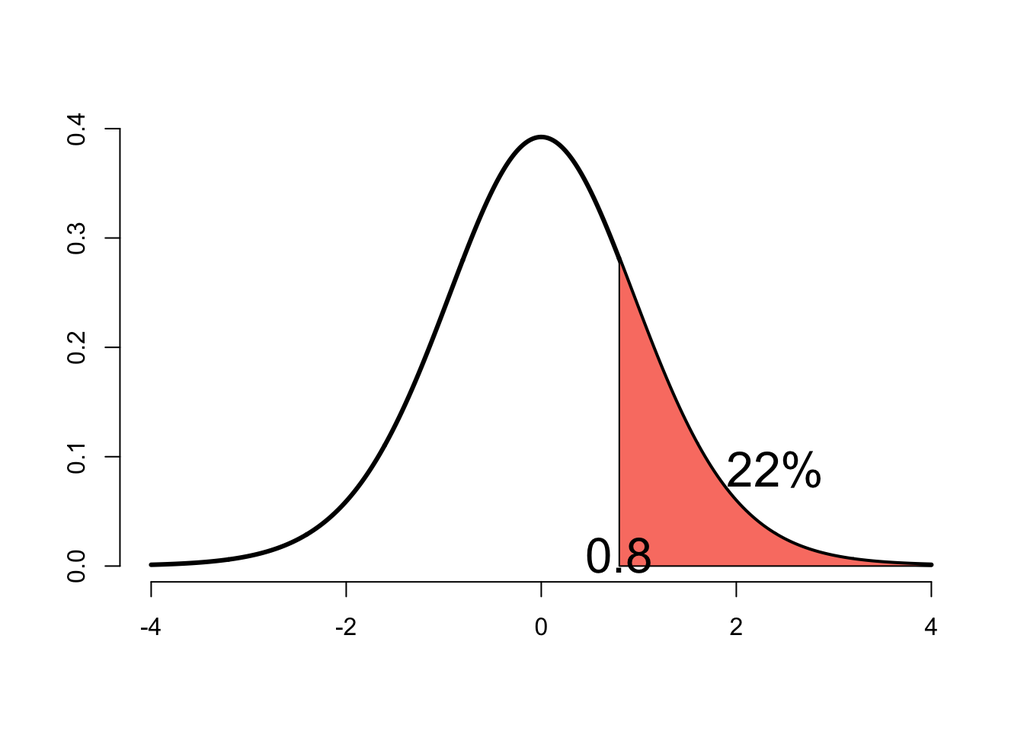

```r
xval <- seq(-4, 4, length = 1000)
yval <- dt(xval, 15)
plot(xval, yval, type = "l", axes = TRUE, frame = FALSE, lwd = 3, xlab = "" , ylab = "")
x <- seq(.8, 4, length = 100)
polygon(c(x, rev(x)), c(dt(x, 15), rep(0, length(x))), col = "salmon")
text(mean(x), mean(dt(x, 15)) + 0.02, "22%", cex = 2)
text(0.8, 0.01, "0.8", cex=2)
```

Therefore, the probability of seeing evidence as extreme or more extreme than that actually obtained is 0.22

### Notes

- By reporting a P-value the reader can perform the hypothesis test at whatever $\alpha$ level he or she chooses.
- If the P-value is less than $\alpha$ you reject the null hypothesis
- For two sided hypothesis test, double the smaller of the two one sided hypothesis test Pvalues
- Don’t just report P-values, give Confidence intervals too!

### Criticisms of the P-value

- P-values only consider significance, unlike Confidence Intervals
- It is difficult with a P-value or result of a hypothesis test to distinguis practical significance form statistical significance
- Absolute measures of the rareness of an event are not good measures of the evidence for or against a hypothesis
- P-values have become abusively used

# Power

- Power is the probability of rejecting the null hypothesis when it is false
- Ergo, power is a good thing; you want more power
- A type II error is failing to reject the null hypothesis when it is false; the probability of a type II error is usually called $\beta$
- Power = $1 - \beta$

### Notes

- Consider our previous example involving RDI
- $H_0 : \mu = 30$ versus $H_a : \mu \gt 30$
- Then power is

$P \big( \frac{\bar{X} - 30}{s / \sqrt{n}} \gt t_{1-\alpha,n-1} \,|\, \mu = \mu_a \big)$

- Note that this is a function that depends on the specific value of $\mu_a$!
- Notice as $\mu_a$ approaches 30 the power approches $\alpha$

## Calculating power

Assume that n is large and that we know $\sigma$ $\begin{align} 1 - \beta & = P \big(\frac{\bar{X} - 30}{\sigma/\sqrt{n}} \gt z_{1-\alpha} | \mu = \mu_a \big) \\ & = P \big(\frac{\bar{X} - \mu_a + \mu_a - 30}{\sigma/\sqrt{n}} \gt z_{1-\alpha} | \mu = \mu_a \big) \\ & = P \big(\frac{\bar{X} - \mu_a}{\sigma/\sqrt{n}} \gt z_{1-\alpha} - \frac{\bar{X} - \mu_a}{\sigma/\sqrt{n}} | \mu = \mu_a \big) \\ & = P \big(Z \gt z_{1-\alpha} - \frac{\bar{X} - \mu_a}{\sigma/\sqrt{n}} | \mu = \mu_a \big) \\ \end{align}$

### Example continued

$0.80 = P \big(Z \gt z_{1-\alpha} - \frac{\mu_a - 30}{\sigma/\sqrt{n}} \,|\, \mu = \mu_a \big)$

- Set $z_{1-\alpha} - \frac{\mu_a - 30}{\sigma\sqrt{n}} = z_{0.20}$ and solve for n

### Notes

- The calculations for $H_a : \mu \lt \mu_0$ is similar
- For $H_a : \mu \ne \mu_0$ calculate the one sided power using $\alpha/2$ (this is only approximately right, it excludes the probability of getting a large TS in the oppisite direction of the truth)
- Power goes up as $\alpha$ gets larger
- Power of a one sided test is greater than the power of the associated two sided test
- Power goes up as $\mu_1$ gets further away from $\mu_0$
- Power goes up as n goes up

## T-tests

- Consider calculating power for a Gossett’s T test for our example
- The power is

$P(\frac{\bar{X} - 30}{S/\sqrt{n}} \gt t_{1-\alpha,n-1} | \mu = \mu_a)$

- Notice that this is equal to

$\begin{aligned} & = P(\sqrt{n}(\bar{X} - 30) \gt t_{1-\alpha,n-1}S|\mu = \mu_a) \\ & = P(\frac{\sqrt{n}(\bar{X} - 30)}{\sigma} \gt t_{1-\alpha,n-1} \frac{S}{\sigma} | \mu = \mu_a) \end{aligned}$

Which still has an S in it, which is random.

$P\big(\frac{\sqrt{n}(\bar{X} - \mu_a)}{\sigma} + \frac{\sqrt{n}(\mu_a - 30)}{\sigma} \gt \frac{t_{1-\alpha,n-1}}{\sqrt{n-1}} \times \sqrt{\frac{(n-1)S^2}{\sigma^2}}\big)$

(where we ommitted the conditional on $\mu_a$ for space)

- This is now equal to

$P\big(Z + \frac{\sqrt{n}(\mu_a - 30)}{\sigma} \gt \frac{t_{1-\alpha,n-1}}{\sqrt{n-1}} \sqrt{\chi^2_{n-1}} \big)$

where Z and $\chi^2_{n-1}$ are independent standard normal and chi-squared random variables

- while computing this probability is outside the scope of this class, it would be easy to approximate with Monte Carlo

## Monte Carlo

simulate pairs with a Z random variable and a chi-sq random variable, and then check to see what is bigger.

Let’s recalculate power for the previous example using the T distribution instead of the normal; here’s the eay way to do it. Let $\sigma = 4$ and $\mu_a - \mu_0 = 2$

```r
power.t.test(n = 16, delta = 2/4, type = "one.sample", alt = "one.sided")
```

```
##
##      One-sample t test power calculation
##
##               n = 16
##           delta = 0.5
##              sd = 1
##       sig.level = 0.05
##           power = 0.6040329
##     alternative = one.sided
```

```r
# The result is 60%
```

Using Monte Carlo

```r
nosim <- 100000
n <- 16
sigma <- 4
mu0 <- 30
mua <- 32
z <- rnorm(nosim)
xsq <- rchisq(nosim, df = n-1)
t <- qt(.95, n-1)
# count the number of times lhs > rhs
# divide by nosim
mean(z + sqrt(n) * (mua - mu0) / sigma > t / sqrt(n -1) * sqrt(xsq))
```

```
## [1] 0.60488
```

```r
## result = 60%
```

- Notice that in both cases, power required a true mean and a true standard deviation
- However in this (and most linear models) the power depends only on the mean (or change in means) divided by the standard deviation